# Random Forests and Boosting

These methods use decision trees as building blocks to build more complex models. Here we will use the ‘Boston’ housing data to explore random forests and boosting. These data are in the MASS package.

The ‘Boston’ dataframe gves housing values and other statisctics in each of 506 suburbs of Boston based on a 1970 census.

## Random Forests

Random forests build lots of bushy trees, and then average them to reduce the variance.

```r
require(randomForest)
require(MASS)
set.seed(101)
dim(Boston)
```

```
## [1] 506  14
```

```r
train <- sample(1:nrow(Boston), 300)
?Boston
```

```
## starting httpd help server ... done
```

Let’s fit a random forest and see how well it performs. We will use the response ‘medv’, the median housing value (in $1000s).

```r
rf.boston <- randomForest(medv~., data=Boston, subset=train)
rf.boston
```

```
##
## Call:
##  randomForest(formula = medv ~ ., data = Boston, subset = train)
##                Type of random forest: regression
##                      Number of trees: 500
## No. of variables tried at each split: 4
##
##           Mean of squared residuals: 12.62686
##                     % Var explained: 84.74
```

The Mean Squared Residuals and the % variance explained are based on OOB or *out-of-bag* estimates, a very clever device in random forests to get honest error estimates. The model reports that ‘mtry=4’, which is the number of variables randomly chosen at each split. Since $p=13$ here, we could try all 13 possible values of ‘mtry’. We will do so below, record the results and make a plot.

```r
oob.err <- double(13)
test.err <- double(13)
for (mtry in 1:13) {
  fit <- randomForest(medv~., data = Boston, subset = train, mtry=mtry, ntree=400)
  oob.err[mtry] <- fit$mse[400]
  pred <- predict(fit, Boston[-train, ])
  test.err[mtry] <- with(Boston[-train,], mean((medv-pred)^2))
  cat(mtry," ")
}
```

```
## 1  2  3  4  5  6  7  8  9  10  11  12  13
```

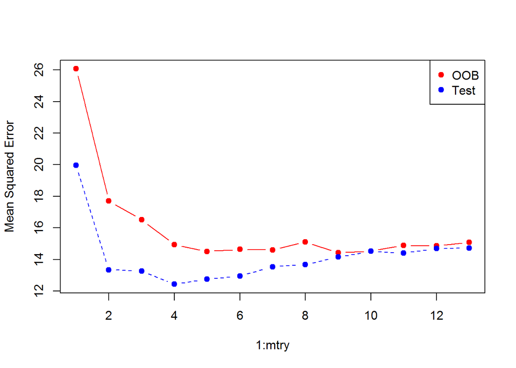

```r
matplot(1:mtry, cbind(test.err,oob.err), pch=19, col=c("red","blue"), type="b", ylab="Mean Squared Error")
legend("topright", legend=c("OOB", "Test"), pch=19, col=c("red","blue"))
```

## Boosting

Boosting builds lots of smaller trees. Unlike random forests, each new tree in boosting tries to patch up the deficiencies of the current ensemble.

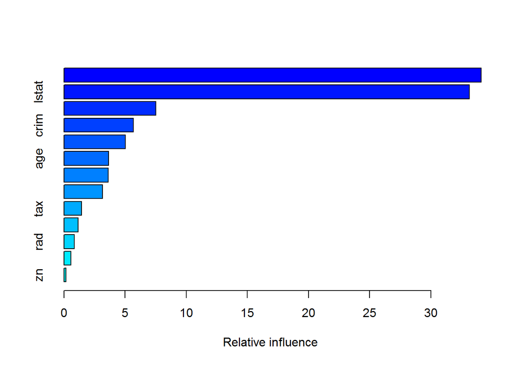

```
##             var    rel.inf
## rm           rm 34.1081546
## lstat     lstat 33.1316086
## dis         dis  7.5120889
## crim       crim  5.6612906
## nox         nox  5.0241727
## age         age  3.6329404
## ptratio ptratio  3.6158409
## black     black  3.1587893
## tax         tax  1.4505711
## chas       chas  1.1445329
## rad         rad  0.8560361
## indus     indus  0.5506076
## zn           zn  0.1533664
```

```r
require(gbm)
boost.boston <- gbm(medv~., data=Boston[train,], distribution="gaussian", n.trees=10000, shrinkage=0.01, interaction.depth=4)
summary(boost.boston)
```

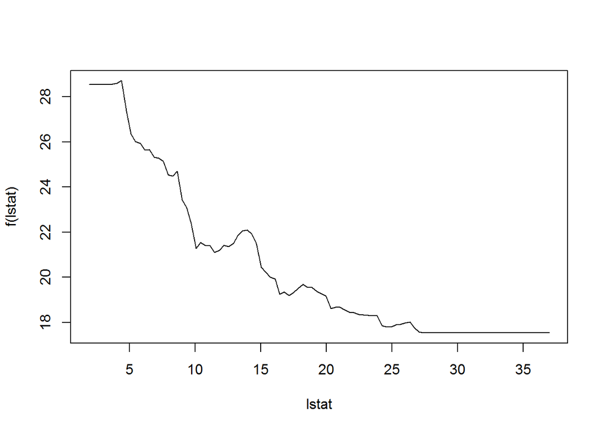

```r
plot(boost.boston, i="lstat")
```

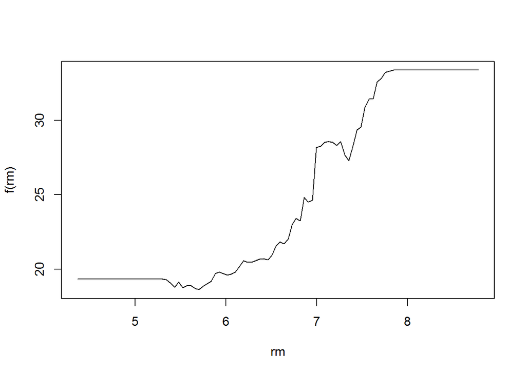

```r
plot(boost.boston, i="rm")
```

Lets make a prediction on the test set. With boosting, the number of trees is a tuning parameter, and if we have too many we can end up overfitting. So we should use cross validation to select the optimal number of trees. We won’t do that here, but rather we will compute the test error as a function of the number of trees and then make a plot.

```r
n.trees <- seq(from=100, to=10000, by=100)
predmat <- predict(boost.boston, newdata=Boston[-train,], n.trees=n.trees)
dim(predmat)
```

```
## [1] 206 100
```

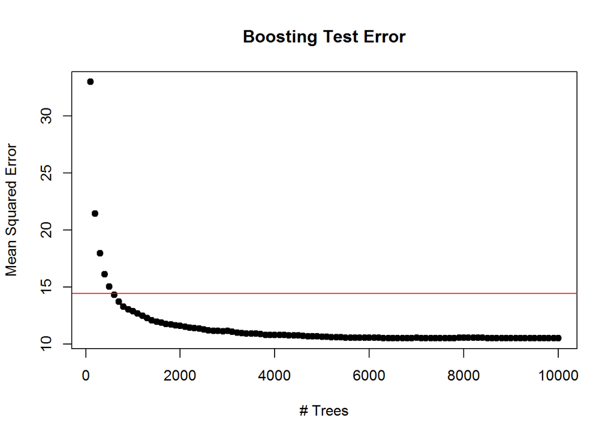

```r
berr <- with(Boston[-train,], apply((predmat-medv)^2,2,mean))
plot(n.trees, berr, pch=19, ylab="Mean Squared Error", xlab="# Trees", main="Boosting Test Error")
abline(h=min(test.err), col="red")
```

The lecturer (Trevor Hastie) says that from experience, Boosting (especially if you’re willing to tweak and tune) will usually outperform Random Forests. However, Random Forests are very easy to do, they won’t overfit and their only tuning parameter is mtry. Once a RF is stable, it remains stable, and adding more trees won’t make much difference whereas a Boosting error would start to overfit and increase. Otherwise, both are very powerful methods.